# Applied Psychometrics: The Steps of Scale Development and Standardization Process

[output not shown]

PSYCH [Vol.9 No.11 , October 2018](https://m.scirp.org/journals/PSYCH/11613)

Applied Psychometrics: The Steps of Scale Development and Standardization Process

[Theodoros A. Kyriazos](https://m.scirp.org/s/searchPaper.action?kw=Theodoros%20A.+Kyriazos&sf=au), [Anastasios Stalikas](https://m.scirp.org/s/searchPaper.action?kw=Anastasios+Stalikas&sf=au)

**Abstract**: This work focuses on presenting the development process of a self-reporting measurement instrument. Numerous scale development procedures are reviewed. They are all summarized into an overall framework of consecutive steps. A concise description is contained in each step. Issues covered comprise the following. First, the theoretical underpinning of the scale construct is described, along with the response specifications and response formats available (most popular like Likert and some more elaborated). Then the item writing guidelines follow together with strategies for discarding poor items when finalizing the item pool. The item selection criteria described comprise an expert panel review, pretesting and item analysis. Finally, the dimensionality evaluation is summarized along with test scoring and standardizing (norming). Scale construction has implications on research conclusions, affecting reliability and the statistical significance of the effects obtained or stated differently the accuracy and sensitivity of the instruments.

**Keywords**: [Test Constriction](https://m.scirp.org/s/searchPaper.action?kw=Test+Constriction&sf=kw), [Scale Development](https://m.scirp.org/s/searchPaper.action?kw=Scale+Development&sf=kw), [Questionnaires](https://m.scirp.org/s/searchPaper.action?kw=Questionnaires&sf=kw), [Self-Report Scales](https://m.scirp.org/s/searchPaper.action?kw=Self-Report+Scales&sf=kw), [Item-Writing](https://m.scirp.org/s/searchPaper.action?kw=Item-Writing&sf=kw), [Scaling](https://m.scirp.org/s/searchPaper.action?kw=Scaling&sf=kw), [Item Analysis](https://m.scirp.org/s/searchPaper.action?kw=Item+Analysis&sf=kw), [Factor Analysis](https://m.scirp.org/s/searchPaper.action?kw=Factor+Analysis&sf=kw), [Expert Panel Review](https://m.scirp.org/s/searchPaper.action?kw=Expert+Panel+Review&sf=kw), [Standardization](https://m.scirp.org/s/searchPaper.action?kw=Standardization&sf=kw), [Norming](https://m.scirp.org/s/searchPaper.action?kw=Norming&sf=kw)

1. Introduction and Basic Concepts

Questionnaire (also called a test or a scale) is defined as a set of items designed to measure one or more underlying constructs, also called latent variables ( Fabrigar & Ebel-Lam, 2007). In other words, it is a set of objective and standardized self-report questions whose responses are then summed up to yield a score. Item score is defined as the number assigned to performance on the item, task, or stimulus ( Dorans, 2018: p. 578). The definition of a questionnaire or test is rather broad and encompasses everything from a scale, to measure life satisfaction (e.g. the SWLS Diener et al., 1985), to complete test batteries such as the Woodcock-Johnson IV battery by Schrank , Mather, and McGrew (2014) comprising cognitive tests, ( Irwing & Hughes, 2018). The scale items are indicators of the measured construct and hence the score is also an indicator of the construct ( Zumbo et al., 2002 ; Singh et al., 2016). Generally, there are attitude, trait, and ability scales ( Irwing & Hughes, 2018). Attitude, ability and intellectual reasoning measures or personality measures are considered as technical tools, equivalent e.g. to a pressure gauge or a voltmeter ( Coolican, 2014). Over the past decades, such instruments became popular in psychology mainly because they provide multiple related pieces of information on the latent construct been assessed ( Raykov, 2012). Scale Development or construction, is the act of assembling or/and writing the most appropriate items that constitute test questions ( Chadha, 2009) for a target population. The target population is as the group for whom the test is developed ( Dorans, 2018). Test development and standardization (or norming) are two related processes where test development comes first and standardization follows. During test development, after item assembly and analysis, the items which are strongest indicators of the latent construct measured are selected and the final pool emerges, whereas in standardization, standard norms are specified ( Chadha, 2009). Effective scale construction has important implications on research inferences, affecting first the quality and the size of the effects obtained and second the statistical significance of those effects ( Furr, 2011), or in other words the accuracy and sensitivity of the instruments ( Price, 2017). A set of standards for assessing standardized tests for psychology and education has been published jointly by the American Educational Research Association, the American Psychological Association, and the National Council on Measurement in Education ( AERA/APA/NCME, 1999, 2014 ; Streiner, Norman, & Cairney, 2015). Generally, successful tests are developed due to some combination of the three following conditions ( Irwing & Hughes, 2018): 1) Theoretical advances (e.g. NEO PI-R by Costa & McCrae, 1995); 2) Empirical advances (e.g. MMPI by Butcher, Dahlstrom, Graham, Tellegen, & Kaemmer, 1989); 3) A practical or market need (e.g. SAT by Coyle & Pillow, 2008).

The purpose of this work is to provide a review of the scale development and standardization process.

2. The Scale Development Process Overview

The scale development process as described by Trochim (2006) is completed in five steps (as quoted by Dimitrov, 2012): 1) Define the measured trait, assuming it is unidimensional. 2) Generate a pool of potential Likert items, (preferably 80-100) rated on a 5 or 7 disagree-agree response scale. 3) Have the items rated by a panel of experts on a 1 - 5 scale on how favorable the items measure the construct (from 1 = strongly unfavorable, to 5 = strongly favorable). 4) Select the items to retain for the final scale. 5) Administer the scale and to some of the responses of all items (raw score of the scale), reversing items that measure something in the opposite direction of the rest of the scale. Because the overall assessment with an instrument is based on the respondent’s scores on all items, the measurement quality of the total score is of particular interest ( Dimitrov, 2012). In a similar vein, Furr (2011) also described it as a process completed in five steps: (a) Define the Construct measured and the Context, (b) Choose Response Format, (c) Assemble the initial item pool, (d) Select and revise items and (e) Evaluate the psychometric properties (see relevant section). Steps (d) and (e) are an iterative process of refinement of the initial pool until the properties of the scale are adequate. Test score then can be standardized (see relevant section).

3. Phase A: Instrument Purpose and Construct Measured

When instruments are developed effectively, they show adequate reliability and validity supporting the use of resulting scores. To reach this goal, a systematic development approach is required ( Price, 2017). However, the development of scales to assess subjective attributes is considered rather difficult and requires both mental and financial resources ( Streiner et al., 2015). The prerequisite is to be aware of all existing scales that could suit the purpose of the measurement instrument you wish to develop, judging their use without any tendency to maximizing deficiencies before embark on any test construction adventure. Then, there is one more consideration: feasibility. Some feasibility dimensions need to be considered are time, cost, scoring, the method of administration, intrusiveness, the consequences of false-positive and false-negative decisions, and so forth ( Streiner et al., 2015). After that, the scale development process can start with the definition of the purpose of the instrument within a specific domain, the instrument score and the constraints inherent in the development ( Dimitrov, 2012 ; Price, 2017). As a rule, in the research field of psychology, the general purpose of a scale is to discriminate between individuals with high levels of the construct being measured from those with lower levels ( Furr, 2011).

However, the test developed should first determine clearly the intended construct been measured. Defining the construct to be measured is a crucial step requiring clarity and specify ( DeVellis,2017;Price,2017). Outlining a construct is possible by connecting ideas to a theory (e.g. the emotional intelligence;

Goleman, 1995). However, constructs in psychology are not directly observable ( Kline, 2009 ; Sawilowsky, 2007 ; Milfont & Fisher, 2010 among many others), thus developers have first to define a general philosophical foundation to connect the construct to a set of observable traits or behaviors ( Price, 2017). For example, the Broaden and Build Theory of positive emotions by Fredrickson ( Fredrickson, 1998, 2001, 2003, 2013) was postulated within the positive psychology movement, initiated by Seligman ( Seligman, 1998 ; Seligman & Csikszentmihalyi, 2000) that perceives psychology in a different perspective from “as usual” ( Seligman & Pawelski, 2003). That is, the philosophical foundation of a test or instrument is a connector between the construct to be measured and a related body of a material called domain ( Nunnally & Bernstein, 1994: p. 295 reproduced by Price, 2017). Dimitrov (2012) offers an illustrative example: various definitions of “self-efficacy” exist in models like the Social Cognitive Theory ( Bandura, 1997), the Theory of Planned Behavior ( Ajzen, 1991), the Transtheoretical Model ( Prochaska, Norcross, Fowler, Follick, & Abrams, 1992), and the Health Action Process Approach ( Schwarzer, 2001).

4. Phase B: Response Scale Specifications

One of the first decisions when designing a questionnaire is whether to include open (allowing answer in the respondents’ own words) or closed questions (forcing responses from a set of choices). The vast majority of items are closed, although some open questions are used in survey research or items requiring a numerical input e.g. age, weight, ( Krosnick & Presser, 2010). Nevertheless, items

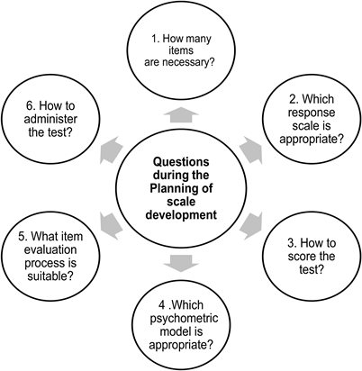

Figure 1. Questions to be answered during planning of the scale development (content by Irwing & Hughes, 2018: pp. 9-10).

used in questionnaires/tests of psychological research are closed-ended because this permits the generated data to be analyzed ( Coolican, 2014 ; Furr, 2011). A third case is a combination of the open and closed-ended format by including an ‘‘other’’ option. This strategy, however, has been proven of imitated efficiency because respondents tend to ignore the other option ( Krosnick & Presser, 2010 ; Lindzey & Guest, 1951 ; Schuman & Scott, 1987). Scaling in closed-ended items can be categorized as 1) categorical or continuous; 2) by their level of measurement, i.e. nominal, ordinal, interval and ratio ( Streiner et al., 2015). In a categorical scale score is obtained by summing (or averaging) items receiving answers with binary values (i.e. 1 = true, 0 = false). In a continuous scale, the scores are summed (or averaged) based on items with numbers assigned to response categories, i.e. from 1 = strongly disagree to 5 = strongly agree for a five-point Likert scale item ( Dimitrov, 2012 ; Barker, Pistrang, & Elliott, 2016). Regardless of ambiguities and disagreements, researchers generally treat Likert-type scales as an interval level of measurement ( Furr, 2011). However, rating scales rated on a ≥ 5-point scale, are not considered an interval-level measurement but continuous ( Streiner et al., 2015). The developer should decide what the response format will be on an early stage, simultaneously with the item generation so that these two have compatibility ( DeVellis, 2017). Response scales come in different formats with several specifications to be considered by the developer (see Figure 2).

4.1. Response Scale Format

Roughly speaking, the response scale format denotes the way items are worded and responses are obtained and evaluated ( Furr, 2011). Common scale formats

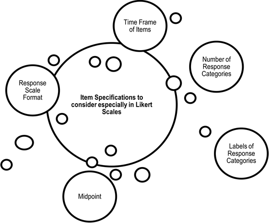

Figure 2. Item Specifications especially pertinent in Likert and Likert-type scales that should be decided along with item writing.

include ( Nunnally & Bernstein, 1994 ; Dimitrov, 2012 ; Barker et al., 2016): (a) Guttman Scaling ( Guttman, 1941, 1944, 1946); (b) Thurstone Scaling ( Thurstone, 1928); (c) Likert Scaling ( Likert, 1932, 1952). (A) and (B) are not equally weighted item scales while (c) is ( DeVellis, 2017). The Classical Measurement Model is more suitable for scales with items being approximately equivalent sensors of the measured construct, like Likert (see also Price, 2017). Generally, scales made up of items that are scored on a continuum and then summed to generate the scale score are more compatible with the Classical Measurement Model (of latent variable measurement) postulating that items are comparable indicators of the underlying construct than with the Item Response Theory that is an alternative measurement perspective ( DeVellis, 2017 ; Price, 2017) and cases(A) and (B) are more suited ( DeVellis, 2017). For this reason, we only briefly describe Guttman and Thurstone Scaling and in more detail the Likert Scaling or generally all continuous and equally weighted scales ( DeVellis, 2017) of direct estimation ( Streiner et al., 2015).

Thurstone Scaling

Thurstone (1927) proposed three methods for developing a unidimensional scale: the method of equal-appearing intervals, the method of successive intervals, and the method of paired comparisons ( Dimitrov, 2012). The central idea in all three methods is that the scale developer devises items that correspond to different levels of the measured attribute ( DeVellis, 2017). Then a group of experts rates the degree the items are representative of the attribute on a scale of 1 (least representative) to 11 = most representative ( Dimitrov, 2012). However, as a rule, the practical problems inherent in using the method with the Classical Measurement Model ( DeVellis, 2017), its demanding development process in combination with comparable results to the Likert scale ( Streiner et al., 2015) often minimizes its advantages.

Likert Scaling

The Likert rating scales and the summated rating scales do not follow a measurement model ( Torgerson, 1958) however, the following assumptions are made: 1) category intervals have approximately equal length, 2) category labels are subjectively set, and 3) a pretest phase during item development is followed by an item analysis of the responses ( Price, 2017). It is not necessary to span the range of weak to strong assertions in this type of scale because the response options offer the possibility of gradations of the measured construct ( DeVellis, 2017).

Semantic Differential

4.2. Response Formatting Considerations

There are many considerations in constructing response scales ( Barker et al., 2016). The first consideration is the number of response categories and their labels, whether to offer a midpoint or a “no opinion” option and other details like the time frame ( Dimitrov, 2012 ; DeVellis, 2017 ; Price, 2017 ; Barker et al., 2016 ; Furr, 2011). These considerations are especially relevant to the Likert scale―by far the most commonly used ( Furr, 2011 ; Dimitrov, 2012 ; Barker et al., 2016).

Number of Response Options

The minimum required is two, i.e. in binary scales (e.g., Agree/Disagree, True/False), but a larger number has benefits and costs ( Furr, 2011). Likert (1932, 1952) scales most often uses 5 points; semantic differential ( Osgood, Suci, & Tannenbaum, 1957) 7 points, and Thurstone’s (1928) 11 points ( Krosnick & Presser, 2010). Other sources suggest 5 points for unipolar and 7 points for bipolar as optimal scale length ( Fabrigar & Ebel-Lam, 2007). Five to nine points are suited for most occasions and in any case ( Streiner at al., 2015 ; Krosnick & Presser, 2010) and are the most frequently used ( Furr, 2011). However, there are really no standards ( Krosnick & Presser, 2010: p. 268). Binary item scoring is mostly used in settings where nonresponse is not a possible option, or/and it is treated as incorrect ( Dorans, 2018) otherwise may result in information loss and ( Streiner et al., 2015) and may be unappealing to respondents ( Streiner et al., 2015 ; also quoting Jones, 1968 ; Carp, 1989).

A potential benefit is that a relatively large number of options allows for finer gradations ( Furr, 2011), just like increasing the accuracy of a microscope. If a response scale is unable to discriminate differences in the target construct, its utility will be limited ( DeVellis, 2017). Additionally, reliability is lower for scales with only two or three points in comparison to scales with more points, this reliability increase disappears after 7 points ( Krosnick & Presser, 2010 also quoting Lissitz & Green, 1975 ; Jenkins & Taber, 1977 ; Martin, 1978 ; Srinivasan & Basu, 1989) and the same is generally true for validity ( Krosnick & Presser, 2010 ; Green & Rao, 1970 ; Lehmann & Hulbert, 1972 ; Lissitz & Green, 1975 ; Martin, 1973, 1978 ; Ramsay, 1973).

The potential cost of having many response options is the increase in random error, rather than the systematic portion of the increase in the target construct ( Furr, 2011 ; DeVellis, 2017). Another issue to consider is the respondents’ capability to discriminate meaningfully among multiple options. Sometimes too many options cause respondents to use only options that are multiples of 5 or 10 ( DeVellis, 2017). Finally, empirical some evidence showed that people in many tasks cannot discriminate easily beyond seven points ( Streiner at al., 2015 also quoting Miller, 1956 ; Hawthorne et al., 2006).

Labels of response options (anchoring)

The descriptors most often tap agreement (Strongly agree to Strongly disagree), but it is possible to construct a Likert scale can be constructed to measure almost any attribute, like agreement (Strongly agree to Strongly disagree), acceptance (Most agreeable - Least agreeable), similarity (Most like me - Least like me), or probability e.g. Most likely - Least likely ( Streiner et al., 2015).

Generally, empirical research deems the use of fully-labeled response options more effective i.e., labeling generate measures with better psychometric quality than does labeling only the endpoints (Krosnick et al., 2005; Furr, 2011 ; Fabrigar & Ebel-Lam, 2007 ; Streiner et al., 2015) or every other point and the endpoints ( Streiner at al., 2015). More specifically, respondents seem to be more influenced by the adjectives on the scale ends than those located in-between. They also tend to be more satisfied when all of the scale points are labeled ( Streiner et al., 2015 ; Dickinson & Zellinger 1980) and tend to choose them more often than non-labeled points ( Streiner et al., 2015).

However, when labeling several practical matters need to be considered. First, labels should differentiate meaningfully the levels of measurement offered. Additionally, they should represent psychologically-equal differences among the response options, as much as possible ( DeVellis, 2017 ; Furr, 2011). The third consideration is the ranking of the response options should be meaningful for all items, logical and consistent ( Furr, 2011).

Mid-points

A neutral midpoint can also be added to dichotomous/bipolar rating scales selecting an even point number of response options ( Furr, 2011), e.g., a strong positive vs. a strong negative attitude. This can be accomplished by specifying an odd number of points, allowing equivocation (“neither agree nor disagree”) or uncertainty (“not sure”). In a unipolar scale, the odd or even number of points issue is probably of little consequence ( Streiner et al., 2015). Common choices for a midpoint include “neither agree nor disagree”, “agree and disagree equally” ( DeVellis, 2017), “neutral” ( Furr, 2011 ; Streiner et al., 2015), or “undecided” ( Price, 2017).

Krosnick and Schuman (1988) and Bishop (1990) suggested that those with less intense attitudes or with limited interest were more prone to select midpoints ( O’Muircheartaigh et al., 1999 ; Krosnick & Presser, 2010). O’Muircheartaigh et al. (1999) also noticed that adding midpoints the reliability and validity of ratings were improved. Also, Structural Equation Modeling on error structures showed that the omission of a middle point resulted in the random selection of one of the closer (and moderate) scale point alternative. This suggests that offering a midpoint choice is probably more appropriate than excluding it ( Krosnick & Presser, 2010). However, a “Don’t know” response option has been empirically proven inefficient (even when offered separately from a mid-point) (Krosnick et al., 2005; Furr, 2011).

However, dependent on the target construct, there may be reasons to exclude equivocation if respondents most likely will use the midpoint choice to avoid answering ( Fabrigar & Ebel-Lam, 2007 ; DeVellis, 2017). There is no criterion other than the needs of the particular research ( Streiner et al., 2015). Empirical analysis of mid-points responses suggests that considering mid-point responses as being the halfway between two opposite ends of the target construct compromises the psychometric properties of the scale ( Furr, 2011 also quoting O’Muircheartaigh et al., 2000).

5. Phase C: Item Generation (Item Pool)

Along with specifying the response format, a parallel step in developing a questionnaire is assembling and/or devising items for the initial pool ( DeVellis, 2017 ; Furr, 2011). The content specification of an instrument requires that the developer: 1) operationalizes the construct by specifying an exhaustive list of potential indicators (items) of the target construct, 2) select from this list the representative sample of indicators ( Dimitrov, 2012). This is perhaps one of the most important steps of the process ( Price, 2017), since no subsequent statistical operation could counterbalance poorly stated or absent items ( Streiner et al., 2015).

Number of items to include

The initial item pool is larger than the final scale set. As a rule, it can be 3 or 4 times larger ( DeVellis, 2017 ; Streiner et al., 2015), or if the construct is rather narrow 2 times larger ( DeVellis, 2017). Writing more good items than required permits selection of the best items, i.e. those which best estimate the target construct and that work well with other items in the scale based on research ( Saville & MacIver, 2017). Content redundancy is an asset during the pool construction because it boosts internal-consistency reliability which, in turn, supports validity ( Devellis, 2017).

Sources of potential items

The first source of information is to examine what others have done ( Furr, 2011 ; Streiner et al., 2015 ; Wechsler (1958) , for example, incorporated into his IQ tests 11 subtests (see also Taylor, 1953 ; Hathaway & McKinley, 1951 for similar strategies). There are a number of reasons for item adaption from previous instruments. First, it saves work. Second, existing items have usually proven to be psychometrically sound and third, as a rule, there are not unlimited ways to ask about a specific problem ( Streiner et al., 2015). Additionally, when writing items there are five different potential sources of ideas ( Streiner et al., 2015): a) the target population (focus group), b) theory, c) existing research, d) expert opinion and/or key informant interviews and e) clinical observation, if applicable. These item sources are not mutually exclusive and a scale developer may use items generated from some or all of these sources ( Streiner et al., 2015). Focus groups are a group of carefully selected people (six to twelve, Willms & Johnson, 1993; p. 61) talking freely and spontaneously about the target construct in the presence of a facilitator ( Streiner et al., 2015 ; Willms & Johnson, 1993). Usually, two or three groups suffice. Conditions that make focus groups ineffective is when the target population is difficult to interact publicly (i.e. because of a certain phobia) or because the construct taps embarrassing behaviors or perceived inadequacies ( Streiner et al., 2015). Theory on the other hand (broadly defined), may include both formal models or vaguely formed ideas of behaviors, especially if the construct belongs to a relatively narrow domain. Additionally, research findings can be a rich source of potential items and subscales either through a literature review of existing studies in the area or an ad hoc research. However, when the construct taps a new area, previous research may be unavailable. Next, the expert opinion practice has no rules on how many experts to use, how to choose them, or how differences among their views can be reconciled. Key informant interviews are interviews with a small number of people who are chosen because of their unique knowledge. Generally, the less that is known about the area under study, the less structured is the interview. There is no set number of people who should be interviewed. Clinical observation is perhaps one of the most fruitful sources of items for scales targeting a clinical population ( Streiner et al., 2015). The information collected from the above procedures (e.g. expert review) should be used for supporting the content aspect of construct validity ( Dimitrov, 2012 ; Streiner et al., 2015 ; DeVellis, 2017).

Item Wording

The item wording is important because the way a question is phrased can determine the response ( Sudman & Bradburn, 1982 ; Bradburn et al., 2004 ; Saris & Gallhofer, 2007 ; Schwartz, 1999). During item-writing, issues such as language clarity, content relevancy, and the use of balanced scales (i.e. with items worded both positively and negatively) are usually considered ( Furr, 2011). Balancing a scale means to word some (e.g. half of them; see BRS by Smith et al., 2008) items positively and other negatively towards the target construct to minimize the response set effect, that is series of similar responses ( Anastasi, 1982 ; Likert, 1932 ; Cronbach, 1950). However, research generally suggests that is inefficient ( Streiner et al., 2015 ; DeVellis, 2017).

The following suggestions were made for item construction of attitude scales ( Gable & Wolfe, 1993: pp. 40-60 ; reproduced by Price, 2017: p. 178): 1) Avoid items in the past tense; 2) Constructing items that include a single thought; 3) Avoid double-negatives; 4) Prefer items with simple sentence structure; 5) Avoid words denoting absoluteness such as only or just, always, none; 6) Avoid items likely to be endorsed by everyone; 7) Avoid items with multiple interpretations; 8) Use simple and clear language; 9) Keep items under 20 words. This means approximating the reading ability of a child aged 11 - 13 years, a reading level used by most newspapers ( DeVellis, 2017 ; Streiner et al., 2015). Specifically, the reading ability of children attending fifth-grade is 14 words and 18 syllables per sentence, i.e., an item (based on continuous text research ( Dale & Chall, 1948 ; Fry, 1977 ; DeVellis, 2017 ; Streiner et al., 2015), thus questionable (see Streiner et al., 2015). Sentences sixth-grade level children can handle contain 15 - 16 words and about 20 syllables. A general rule for efficient implementation of reading ability rules is common sense ( DeVellis, 2017), and the same is true for the item writing rules ( Krosnick & Presser, 2010).

6. Phase D: Item Evaluation

The item generation phase is completed when an expert panel reviews the item pool ( DeVellis, 2017). The items generated are reviewed for quality and relevance by the expert panel ( Morrison & Embretson, 2018) or /and by pilot testing ( Price, 2017). Generally, after reviewing items by expert groups it is also a common practice to pilot test items to acquire data for a first item analysis ( Irwing & Hughes, 2018 also quoting DeMaio & Landreth, 2004 ; Presser & Blair, 1994 ; Willis, Schechter, & Whitaker, 2000). Alternatively, four additional methods can be used to provide feedback on the relevance, clarity, and unambiguousness: Field pretests, cognitive interviews, randomized experiments and focus groups

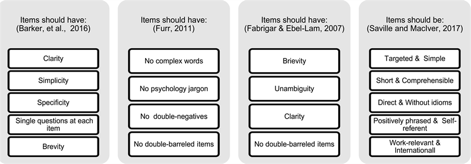

Figure 3. Key principles for successful item writing as suggested by four different sources in scale development literature.

Content adapted by Barker et al., 2016: pp. 111-112 ; DeVellis, 2017: p. 101 .

( Irwing & Hughes, 2018 ; Streiner et al., 2015). The item validity is complemented by item analysis to estimate the psychometric quality of each item in measuring the target construct (e.g., Ackerman, 1992 ; Allen & Yen, 1979 ; Anastasi & Urbina, 1997 ; Clauser, 2000 ; Crocker & Algina, 1986 ; Haladyna, 1999 ; Janda, 1998 ; Wilson, 2005 ; Wright & Masters, 1982 as quoted by Dimitrov, 2012). Item analysis results from support construct validity ( Streiner et al., 2015).

Expert Panel Review of Items

Expert reviews may include: 1) content reviews, which provide input about the initial pool of items regarding their relevance to the content domain, accuracy, and completeness; 2) sensitivity reviews, evaluating potential item bias; and 3) standard setting, a process in which experts identify cutoff scores for criterion-referenced decisions on levels of performance or diagnostic classifications ( Dimitrov, 2012).

Pilot testing the Items (Pretesting)

So far, the test construction depends on theory, prior empirical evidence, and subjective judgments based on expert knowledge. The next stages include administration to an appropriate sample(s) ( Irwing & Hughes, 2018). These are considered probably the quintessence of the scale development process perhaps after the item development ( DeVellis, 2017). Pilot testing involves testing the scale to a representative sample from the target population to obtain statistical information on the items, comments, and suggestions ( Streiner et al., 2015). Descriptive statistics then will go through item analysis providing important information for each item ( Price, 2017). Item analysis is used for selecting the best items. An item analysis allows detection of items that are: 1) ambiguous, 2) incorrectly keyed or scored, 3) too easy or too hard, and 4) not discriminative enough ( Price, 2017). This phase generally comprises the following statistical techniques: a) Examine the intercorrelations between all item pairs based both on panel expert ratings and pilot testing; b) Remove items with low correlation with the total score; c) Track the differences between the item means and the 25% of the expert ratings. Items that have higher values are potentially better discriminators of the target construct; and d) Take into account the characteristics of each item and practical considerations retain items with high item-total correlations and high discrimination ( Dimitrov, 2012 ; Trochim, 2006).

Criteria for Item Analysis

Items that are similar insofar as they share relevance to the target construct and not with regards to any other aspect can be good items and not be discarded ( DeVellis, 2017). The item quality criterion is a high correlation with the true score of the latent variable. So, the highest intercorrelated items indicated by inspecting the correlation matrix are preferable. If items with negative correlations with other items occur, then reverse scoring may be considered. Items positively correlated with some and negatively correlated with others should be eliminated in a homogeneous set if reverse scoring items do not eliminate negative correlations ( DeVellis, 2017). See Figure 4for an overview of the pilot testing criteria proposed by Streiner et al. (2015: p. 94) . Note also that Item analysis can be carried-out within the SEM context, however this approach is beyond the scopes of this work. Refer to Raykov (2012) for details.

Response Bias

An additional consideration when selecting items is whether items cause response sets which either bias responses or generate response artifacts. Generally, this is mainly attributed to the sequence of items. The most common response sets are: yeah-saying (acquiescence bias―respondents agree with the statements), nay-saying (respondents reject the statements), consistency and availability artifacts, halo ( Thorndike, 1920 ; Campbell & Fiske, 1959: p. 84), and

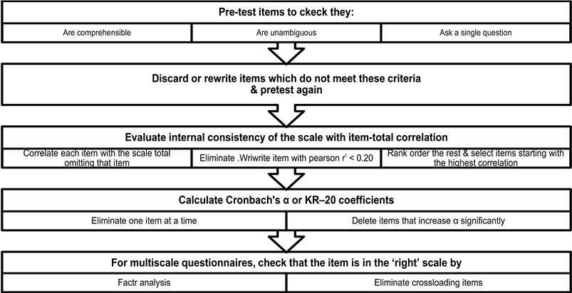

Content is based on Streiner et al. (2015: p. 94) .

Figure 4. Overview of the pilot testing procedure and item analysis procedure.

social desirability artifacts, i.e. respondents try to present themselves in a favorable light Likert scales may also present a central tendency bias―respondents avoid selection of extreme scale categories ( Irwing & Hughes, 2018 ; Dimitrov, 2012).

7. Phase E: Testing the Psychometric Properties of the Scale

In the final phase of the test development process, a validation study is always carried out in a large and representative development sample ( DeVellis, 2017) to estimate further the psychometric properties of the scale ( Dimitrov, 2012). That is, after an initial pool of items has been developed and pilot tested (pre-tested) in a representative sample, the performance of the individual items to select the most appropriate to include in the final scale and to examine scale dimensionality ( DeVellis, 2017). The statistical techniques used for these purposes is item analysis (like during pretesting) and factor analysis ( Price, 2017). Criteria for item selection regarding item analysis in this phase are the same as in pretesting ( Singh et al., 2016). Dimensionality of a scale is examined with Exploratory Factor Analysis and Confirmatory Factor Analysis ( Furr, 2011 ; Singh et al., 2016). Usually, scales are administered, analyzed, revised, and readministered a number of times before their psychometric properties are acceptable ( Irwing & Hughes, 2018 ; Furr, 2011).

7.1. Dimensionality

A scale’s dimensionality, or factor structure, refers to the number and nature of the variables reflected in its items ( Furr, 2011). A scale measuring a single construct (e.g. property or ability) is called unidimensional. This means there is a single latent variable (factor) underlies the scale items. In contrast, a scale measuring two or more constructs (latent variables) is multidimensional ( Dimitrov, 2012).

Developers examine several issues regarding a scale’s dimensionality in this phase of the scale development process. First, they seek to define the number of dimensions underneath the construct. These are called latent variables (factors) and are measured by scale items. A scale is unidimensional when all items tap a single construct (e.g. self-esteem). On the other hand, a scale is multidimensional when scale items tap two or more latent variables, e.g. personality tests ( Dimitrov, 2012). If a scale is multidimensional, the developer also examines whether the dimensions are correlated with each other. Finally, in a multidimensional scale, the latent variables must be interpreted according to the theoretical background to see what dimensions they tap, identifying the nature of the construct the dimensions reflect ( Furr, 2011) demonstrating construct validity ( Streiner et al. (2015) and calculate the reliability of each one. Factor analysis has the answers to dimensionality questions (see Figure 5).

7.2. Factor Analysis

“Factor analysis is a statistical technique that provides a rigorous approach for

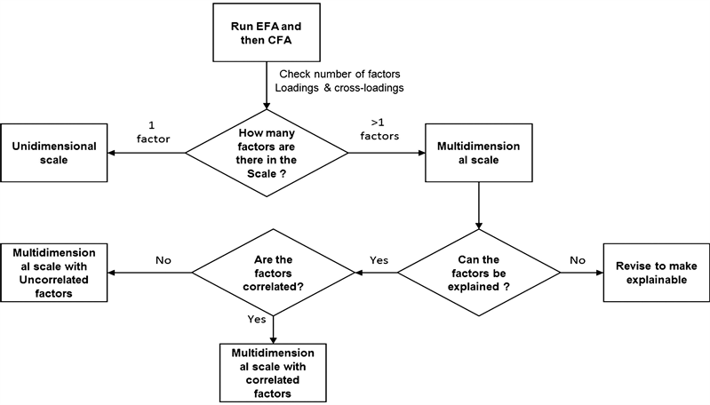

Source: Adapted by Furr, 2011: p. 26 .

Figure 5. The process of dimensionality evaluation of the scale under development and issues related with it.

confirming whether the set of test items comprises a test function in a way that is congruent with the underlying G theory of the test” ( Price, 2017: p. 180), based on the classical measurement theory, also termed Classical Test Theory ( DeVellis, 2017). Factor analysis is an integral part of scale development. It permits data to be analyzed to determine the number of underlying factors bet heath a group of items called factor so that analytic procedures of the psychometric properties like Cronbach’s alpha ( Cronbach, 1951) correlations with other constructs can be performed properly. Eventually, through factor identification insights into the latent variable nature underlying the scale items is gained ( DeVellis, 2017). A factor is defined as an unobserved or latent variable representative of a construct ( Price, 2017: p. 236).

The detailed description of these techniques is beyond the scope of this work but you can refer to Kyriazos (2018a, 2018b) for a complete description of the construct validation process. For scale validation studies refer to Howard et al. (2016) , El Akremi, Gond, Swaen, De Roeck, and Igalens (2015) , Konrath, Meier, Bushman (2017) . Pavot (2018) also suggest reviewing Lyubomirsky and Lepper (1999) , Seligson, Huebner, and Valois (2003) and Diener et al. (2010) .

7.3. Item Response Theory (IRT)

There is also an alternative to the classical test theory model called Item response theory (IRT). IRT is often presented as a superior alternative to CTT (see De Boeck & Wilson, 2004 ; Embretson & Reise, 2010 ; Nering & Ostini, 2010 ; Reise & Revicki, 2015 quoted by DeVellis, 2017). IRT is a model-based measurement approach using item response patterns and a person’s abilities. In IRT, personal responses to each scale item are explainable based on his or her ability level. The respondent’s ability is represented by a monotonically increasing function, based on response patterns ( Price, 2017).

According to IRT, several factors affect a person’s responses. Along with the person’s perceived level of the construct being measured by each scale item, other item properties potentially affecting responses are: (a) item difficulty, (b) item discrimination, and (c) guessing. In most IRT applications in the context of psychology, researchers estimate both psychometric properties at the item level and at the scale level. IRT includes many specific measurement models as a function of different factors potentially affecting individual responses. However, all IRT models are framed according to the probability of a respondent to respond in a specific manner to an item, as a result of a specific level of the underlying behavior. The simplest IRT measurement models comprise only item difficulty while more complex models also comprise two or more item parameters, such as item discrimination and guessing. There are different models for dichotomous items and different for polytomous items ( Furr, 2011). IRT models also vary according to the number of item response options.

The effectiveness of a technique is a function of the theoretical framework of the target construct. IRT scoring is used in tests of cognitive ability, however, in other situations, this type of scoring may not be desirable ( Irwing & Hughes, 2018). A combination of CTT and TRT was suggested as an alternative option ( Embretson & Hershberger, 1999 ; DeVellis, 2017 ; Irwing & Hughes, 2018). In most cases a common practice in test development involves a combination either of confirmatory factor analysis (CFA) and IRT ( Irwing & Hughes, 2018) or more commonly a combination of EFA and CFA ( Steger et al., 2006 ; Fabrigar & Wegener, 2012 ; Kyriazos, 2018a).

7.4. Test Scoring and Standardization (Norming)

Raw scale scores can either be based on a unit-weighted sum of item scores or on factor scores. Unit weighted scoring schemas, generate standardized scores using an appropriate standardization sample, or normative sample ( Dimitrov, 2012), for example, stanine, sten, and t scores ( Smith & Smith, 2005). Unit weighted sums of item scores without standardization may be considered at some research frameworks. Box-Cox procedures ( Box & Cox, 1964) to estimate the power to which the scale score should be raised to follow normality. Subsequently, the scale score is also raised to the previously estimated power and standardized. Standardization (or norming) is carried out by subtracting the mean transformed score from the transformed scale scores and dividing by the standard deviation of the transformed scores ( Irwing & Hughes, 2018). A standardized score denotes the relative position of each respondent in the target population ( Dimitrov, 2012).

Streiner et al. (2015) note the following: (A) Variable weighting on scale items is effective only under certain conditions. (B) if a test is constructed for local/limited use only the sum of the items is probably sufficient. To enable comparison of the results with other instruments, scores is suggested to transformed into percentiles, into z-scores or T-scores. (C) For measurement of attributes that are not the same in males and females, or for attributes that show development changes then separate age and/or age-sex norms can be considered ( Streiner et al., 2015).

8. Summary & Conclusions

Experts suggest that effective measurement is the cornerstone of scientific research ( DeVellis, 2017 ; Netemeyer, Bearden, & Sharma, 2003) and it is an integral part of the latent variable model ( Slavec & Novsek, 2012). Generally, there are attitude, trait, and ability measures. The purpose of scaling is to construct a scale with specific measurement characteristics for the construct measured. The most commonly employed response formats in all psychology are the Likert type, multiple choice, or forced-choice items. Scaling generally is divided into the types established by Thurstone (1927, 1928) , Likert (1932, 1952) , or Guttman (1941, 1944, 1946) . In Likert scaling the response levels are anchored with consecutive integer values, each corresponding to verbal labels indicating approximately evenly spaced intervals and it is the most popular scale in measures of psychology ( Dimitrov, 2012 ; Furr, 2011 , Barker et al., 2016). To a degree, the scaling type and the response format, have an impact on item writing and on the scale development as a whole ( Irwing & Hughes, 2018). An item pool should be as rich as possible for the developing scale. It should contain numerous items pertinent to the target construct ( DeVellis, 2017). Steps of an instrument development process involves the following: 1) the definition of instrument purpose, domain and construct; 2) defining the response scale format; 3) item generation to construct an item pool 2 - 4 times larger than the desired length of the final scale version; 4) item selection based on expert panel reviews and/or pretesting to maximize instrument reliability with item analysis; 5) large-scale validation study(s) to establish construct validity with supplementary item analysis, factor analysis and to standardize the scale scores.

Construct validation studies to evaluate scale dimensionality and norming is a necessary step in scale development after the pool is examined by experts and/or pretesting. The reliability of measurements signifies the degree to which a score shows accuracy, consistency, and replicability. Construct validity is mainly evidenced by the correlational and measurement consistency of the target construct and its items (indicators) mainly by carving out a factor analysis ( Dimitrov, 2012). Scales which are developed thoughtfully and precisely have a greater potential of growing into questionnaires that measure real-world criteria more accurately ( Saville & MacIver, 2017).

**Cite this paper**: Kyriazos, T. and Stalikas, A. (2018) Applied Psychometrics: The Steps of Scale Development and Standardization Process. *Psychology*, **9**, 2531-2560. doi: 10.4236/psych.2018.911145.

References

[1] Ackerman, T. A. (1992). A Didactic Explanation of Item Bias, Item Impact, and Item Validity from a Multidimensional Perspective. Journal of Educational Measurement, 29, 67-91. https://doi.org/10.1111/j.1745-3984.1992.tb00368.x

[2] Aiken, L. R. (2002). Attitudes and Related Psychosocial Constructs: Theories, Assessment and Research. Thousand Oaks, CA: Sage.

[3] Aitken, R. C. B. (1969). A Growing Edge of Measurement of Feelings. Proceedings of the Royal Society of Medicine, 62, 989-92.

[4] Ajzen, I. (1991). The Theory of Planned Behavior. Organizational Behavior and Human Decision Processes, 50, 179-211. https://doi.org/10.1016/0749-5978(91)90020-T

[5] Allen, M. J., & Yen, W. M. (1979). Introduction to Measurement Theory. Monterey, CA: Brooks/Cole.

[6] American Educational Research Association, American Psychological Association, & National Council on Measurement in Education (AERA/APA/NCME) (1999). Standards for Educational and Psychological Testing (2nd ed.). Washington DC: Authors.

[7] American Educational Research Association, American Psychological Association, & National Council on Measurement in Education (AERA/APA/NCME) (2014). Standards for Educational and Psychological Testing (3rd ed.). Washington DC: Authors.

[8] Anastasi, A. (1982). Psychological Testing (5th ed.). Macmillan, New York.

[9] Anastasi, A., & Urbina, S. (1996). Psychological Testing (7th ed.). New York, ΝY: Pearson.

[10] Bandura, A. (1997). Self-Efficacy: The Exercise of Control. New York, NY: Freeman.

[11] Barker, C., Pistrang, N., & Elliott, R. (2016). Research Methods in Clinical Psychology: An Introduction for Students and Practitioners (3rd ed.). Oxford, UK: John Wiley & Sons, Ltd. https://doi.org/10.1002/9781119154082

[12] Bishop, G. F. (1990). Issue Involvement and Response Effects in Public Opinion Surveys. Public Opinion Quarterly, 54, 209-218. https://doi.org/10.1086/269198

[13] Box, G. E. P., & Cox, D. R. (1964). An Analysis of Transformations. Journal of the Royal Statistical Society. Series B (Methodological), 26, 211-254.

[14] Bradburn, N. M., Sudman, S., & Wansink, B. (2004). Asking Questions: The Definitive Guide to Questionnaire Design—For Market Research, Political Polls, and Social and Health Questionnaires. San Francisco, CA: Jossey-Bass.

[15] Butcher, J. N., Dahlstrom, W. G., Graham, J. R., Tellegen, A., & Kaemmer, B. (1989). Minnesota Multiphasic Personality Inventory-2 (MMPI-2). Manual for Administration and Scoring. Minneapolis: University of Minnesota Press.

[16] Campbell, D. T., & Fiske, D. W. (1959). Convergent and Discriminant Validation by the Multitrait-Multimethod Matrix. Psychological Bulletin, 56, 81-105.  
https://doi.org/10.1037/h0046016

[17] Carp, F. M. (1989). Maximizing Data Quality in Community Studies of Older People. In M. P. Lawton, & A. R. Herzog (Eds.), Special Research Methods for Gerontology (pp. 93-122). Amityville, NY: Baywood Publishing.

[18] Chadha, N. K. (2009). Applied Psychometry. New Delhi, IN: Sage Publications.

[19] Clauser, B. E. (2000). Recurrent Issues and Recent Advances in Scoring Performance Assessments. Applied Psychological Measurement, 24, 310-324.  
https://doi.org/10.1177/01466210022031778

[20] Coolican, H. (2014). Research Methods and Statistics in Psychology (6th ed.). New York: Psychology Press.

[21] Costa, P. T., & McCrae, R. R. (1995). Domains and Facets: Hierarchical Personality Assessment Using the Revised NEO Personality Inventory. Journal of Personality Assessment, 64, 21-50. https://doi.org/10.1207/s15327752jpa6401_2

[22] Coyle, T. R., & Pillow, D. R. (2008). SAT and ACT Predict College GPA after Removing g. Intelligence, 36, 719-729. https://doi.org/10.1016/j.intell.2008.05.001

[23] Crocker, L., & Algina, J. (1986). Introduction to Classical and Modern Test Theory. New York: Holt, Rinehart & Winston.

[24] Cronbach, L. J. (1950). Further Evidence on Response Sets and Test Design. Educational and Psychological Measurement, 10, 3-31.  
https://doi.org/10.1177/001316445001000101

[25] Cronbach, L. J. (1951). Coefficient Alpha and the Internal Structure of Tests. Psychometrika, 16, 297-334. https://doi.org/10.1007/BF02310555

[26] Dale, F., & Chall, J. E. (1948). A Formula for Predicting Readability: Instructions. Education Research Bulletin, 27, 37-54.

[27] De Boeck, P., & Wilson, M. (2004). Explanatory Item Response Models: A Generalized Linear and Nonlinear Approach. New York: Springer.  
https://doi.org/10.1007/978-1-4757-3990-9

[28] Demaio, T., & Landreth, A. (2004). Do Different Cognitive Interview Methods Produce Different Results. In S. Presser, J. Rothgeb, M. Couper, J. Lessler, E. Martin, J. Martin, & E. Singer (Eds.), Questionnaire Development and Testing Methods. Hoboken, NJ: Wiley.

[29] DeVellis, R. F. (2017). Scale Development: Theory and Applications (4th ed.). Thousand Oaks, CA: Sage.

[30] Dickinson, T. L., & Zellinger, P. M. (1980). A Comparison of the Behaviorally Anchored Rating Mixed Standard Scale Formats. Journal of Applied Psychology, 65, 147-154.  
https://doi.org/10.1037/0021-9010.65.2.147

[31] Diener, E., Emmons, R. A., Larsen, R. J., & Griffin, S. (1985). The Satisfaction with Life Scale. Journal of Personality Assessment, 49, 71-75.  
https://doi.org/10.1207/s15327752jpa4901_13

[32] Diener, E., Wirtz, D., Tov, W., Kim-Prieto, C., Choi, D. W., Oishi, S. et al. (2009). New Well-Being Measures: Short Scales to Assess Flourishing and Positive and Negative Feelings. Social Indicators Research, 97, 143-156.  
https://doi.org/10.1007/s11205-009-9493-y

[33] Diener, E., Wirtz, D., Tov, W., Kim-Prieto, C., Choi, D., Oishi, S., & Biswas-Diener, R. (2010). New Wellbeing Measures: Short Scales to Assess Flourishing and Positive and Negative Feelings. Social Indicators Research, 97, 143-156.  
https://doi.org/10.1007/s11205-009-9493-y

[34] Dimitrov, D. M. (2012). Statistical Methods for Validation of Assessment Scale Data in Counseling and Related Fields. Alexandria, VA: American Counseling Association.

[35] Dorans, N. J. (2018). Scores, Scales, and Score Linking. In P. Irwing, T. Booth, & D. J. Hughes (Eds.), The Wiley Handbook of Psychometric Testing: A Multidisciplinary Reference on Survey, Scale and Test Development, V.II (pp. 573-606). Hoboken, NJ: Wiley. https://doi.org/10.1002/9781118489772.ch19

[36] El Akremi, A., Gond, J.-P., Swaen, V., De Roeck, K., & Igalens, J. (2015). How Do Employees Perceive Corporate Responsibility? Development and Validation of a Multidimensional Corporate Stakeholder Responsibility Scale. Journal of Management, 44, 619-657. https://doi.org/10.1177/0149206315569311

[37] Embretson, S. E., & Hershberger, S. L. (1999). Summary and Future of Psychometric Models in Testing. In S. E. Embretson, & S. L. Hershberger (Eds.), The New Rules of Measurement (pp. 243-254). Mahwah, NJ: Lawrence Erlbaum.  
https://doi.org/10.4324/9781410603593

[38] Embretson, S. E., & Reise, S. P. (2010). Item Response Theory (2nd ed.). New York, NY: Routledge Academic.

[39] Fabrigar, L. R., & Ebel-Lam, A. (2007). Questionnaires. In N. J. Salkind (Ed.), Encyclopedia of Measurement and Statistics (pp. 808-812). Thousand Oaks, CA: Sage.

[40] Fabrigar, L. R., & Wegener, D. T. (2012). Exploratory Factor Analysis. New York, NY: Oxford University Press, Inc.

[41] Fredrickson, B. L. (1998). Cultivated Emotions: Parental Socialization of Positive Emotions and Self-Conscious Emotions. Psychological Inquiry, 9, 279-281.  
https://doi.org/10.1207/s15327965pli0904_4

[42] Fredrickson, B. L. (2001). The Role of Positive Emotions in Positive Psychology: The Broaden-and-Build Theory of Positive Emotions. American Psychologist, 56, 218-226.  
https://doi.org/10.1037/0003-066X.56.3.218

[43] Fredrickson, B. L. (2003). The Value of Positive Emotions: The Emerging Science of Positive Psychology Is Coming to Understand Why It’s Good to Feel Good. American Scientist, 91, 330-335.

[44] Fredrickson, B. L. (2013). Positive Emotions Broaden and Build. In Advances in Experimental Social Psychology (Vol. 47, pp. 1-53). Cambridge, MA: Academic Press.

[45] Fry, E. (1977). Fry’s Readability Graph: Clarifications, Validity, and Extension to Level 17. Journal of Reading, 21, 249.

[46] Furr, R. M. (2011). Scale Construction and Psychometrics for Social and Personality Psychology. New Delhi, IN: Sage Publications. https://doi.org/10.4135/9781446287866

[47] Gable, R. K., & Wolfe, M. B. (1993). Instrument Development in the Affective Domain: Measuring Attitudes and Values in Corporate and School Settings (2nd ed.). Boston, MA: Kluwer. https://doi.org/10.1007/978-94-011-1400-4

[48] Green, P. E., & Rao, V. R. (1970). Rating Scales and Information Recovery—How Many Scales and Response Categories to Use? Journal of Marketing, 34, 33-39.  
https://doi.org/10.2307/1249817

[49] Guttman, L. (1941). The Quantification of a Class of Attributes: A Theory and Method for Scale Construction. In P. Horst (Ed.), The Prediction of Personal Adjustment (pp. 321-348). New York: Social Science Research Council.

[50] Guttman, L. (1946). An Approach for Quantifying Paired Comparisons and Rank Order. Annals of Mathematical Statistics, 17, 144-163.  
https://doi.org/10.1214/aoms/1177730977

[51] Guttman, L. A. (1944). A Basis for Scaling Qualitative Data. American Sociological Review, 9, 139-150. https://doi.org/10.2307/2086306

[52] Haladyna, T. M. (1999). Developing and Validating Multiple-choice Items (2nd ed.). Mahwah, NJ: Erlbaum.

[53] Haladyna, T. M. (2004). Developing and Validating Multiple-Choice Test Items. Mahwah, NJ: Erlbaum.

[54] Harter, S. (1982). The Perceived Competence Scale for Children. Child Development, 53, 87-97. https://doi.org/10.2307/1129640

[55] Hathaway, S. R., & McKinley, J. C. (1951). Manual for the Minnesota Multiphasic Personality Inventory (Rev. ed.). New York: Psychological Corporation.

[56] Hawthorne, G., Mouthaan, J., Forbes, D., & Novaco, R. W. (2006). Response Categories and Anger Measurement: Do Fewer Categories Result in Poorer Measurement? Development of the DAR5. Social Psychiatry and Psychiatric Epidemiology, 41, 164-172.  
https://doi.org/10.1007/s00127-005-0986-y

[57] Hayes, M. H. S., & Patterson, D. G. (1921). Experimental Development of the Graphic Rating Method. Psychological Bulletin, 18, 98-99.

[58] Heise, D. R. (1970). Chapter 14. The Semantic Differential and Attitude Research. In G. F. Summers (Ed.), Attitude Measurement (pp. 235-253). Chicago, IL: Rand McNally.

[59] Hoek, J. A., & Gendall, P. J. (1993). A New Method of Predicting Voting Behavior. International Journal of Market Research, 35, 1-14.  
https://doi.org/10.1177/147078539303500405

[60] Howard, J., Gagné, M., Morin, A. J., & Van den Broeck, A. (2016). Motivation Profiles at Work: A Self-Determination Theory Approach. Journal of Vocational Behavior, 95-96, 74-89. https://doi.org/10.1016/j.jvb.2016.07.004

[61] Huskisson, E. C. (1974). Measurement of Pain. The Lancet, 304, 1127-1131.  
https://doi.org/10.1016/S0140-6736(74)90884-8

[62] Irwing, P., & Hughes, D. J. (2018). Test Development. In P. Irwing, T. Booth, & D. J. Hughes (Eds.), The Wiley Handbook of Psychometric Testing: A Multidisciplinary Reference on Survey, Scale and Test Development, V.I (pp. 4-47). Hoboken, NJ: Wiley.

[63] Janda, L. H. (1998). Psychological Testing: Theory and Applications. Boston, MA: Allyn & Bacon.

[64] Jenkins, G. D., & Taber, T. D. (1977). A Monte Carlo Study of Factors Affecting Three Indices of Composite Scale Reliability. Journal of Applied Psychology, 62, 392-398.  
https://doi.org/10.1037/0021-9010.62.4.392

[65] Jones, R. R. (1968). Differences in Response Consistency and Subjects’ Preferences for Three Personality Response Formats. In Proceedings of the 76th Annual Convention of the American Psychological Association (pp. 247-248) Washington DC.

[66] Kline, R. B. (2009). Becoming a Behavioral Science Researcher: A Guide to Producing Research That Matters. New York: Guilford Publications.

[67] Konrath, S., Meier, B. P., & Bushman, B. J. (2017). Development and Validation of the Single Item Trait Empathy Scale (SITES). Journal of Research in Personality, 73, 111-122. https://doi.org/10.1016/j.jrp.2017.11.009

[68] Krosnick, J. A., & Presser, A. (2010). Question and Questionnaire Design. In P. V. Marsden, & J. D. Wright (Eds.), Handbook of Survey Research (2nd ed., pp. 264-313). Bingley, UK: Emerald.

[69] Krosnick, J. A., & Schuman, H. (1988). Attitude Intensity, Importance, and Certainty and Susceptibility to Response Effects. Journal of Personality and Social Psychology, 54, 940-952. https://doi.org/10.1037/0022-3514.54.6.940

[70] Kyriazos, T. A. (2018a). Applied Psychometrics: The 3-Faced Construct Validation Method, a Routine for Evaluating a Factor Structure. Psychology, 9, 2044-2072.  
https://doi.org/10.4236/psych.2018.98117

[71] Kyriazos, T. A. (2018b). Applied Psychometrics: Sample Size and Sample Power Considerations in Factor Analysis (EFA, CFA) and SEM in General. Psychology, 9, 2207-2230.  
https://doi.org/10.4236/psych.2018.98126

[72] Lawshe, C. H. (1975). A Quantitative Approach to Content Validity. Personnel Psychology, 28, 563-575. https://doi.org/10.1111/j.1744-6570.1975.tb01393.x

[73] Lehmann, D. R., & Hulbert, J. (1972). Are Three-Point Scales Always Good Enough? Journal of Marketing Research, 9, 444-446. https://doi.org/10.2307/3149313

[74] Likert, R. (1932). A Technique for the Measurement of Attitudes. Archives of Psychology, 140, 1-55.

[75] Likert, R. A. (1952). A Technique for the Development of Attitude Scales. Educational and Psychological Measurement, 12, 313-315.

[76] Lindzey, G. G., & Guest, L. (1951). To Repeat—Check Lists Can Be Dangerous. Public Opinion Quarterly, 15, 355-358. https://doi.org/10.1086/266315

[77] Lissitz, R. W., & Green, S. B. (1975). Effect of the Number of Scale Points on Reliability: A Monte Carlo Approach. Journal of Applied Psychology, 60, 10-13.  
https://doi.org/10.1037/h0076268

[78] Lynn, M. R. (1986). Determination and Quantification of Content Validity. Nursing Research, 35, 382-386. https://doi.org/10.1097/00006199-198611000-00017

[79] Lyubomirsky, S., & Lepper, H. S. (1999). A Measure of Subjective Happiness: Preliminary Reliability and Construct Validation. Social Indicators Research, 46, 137-155.  
https://doi.org/10.1023/A:1006824100041

[80] Martin, W. S. (1973). The Effects of Scaling on the Correlation Coefficient: A Test of Validity. Journal of Marketing Research, 10, 316-318. https://doi.org/10.2307/3149702

[81] Martin, W. S. (1978). Effects of Scaling on the Correlation Coefficient: Additional Considerations. Journal of Marketing Research, 15, 304-308.  
https://doi.org/10.2307/3151268

[82] McCullough, M. E., Emmons, R. A., & Tsang, J. (2002). The Grateful Disposition: A Conceptual and Empirical Topography. Journal of Personality and Social Psychology, 82, 112-127. https://doi.org/10.1037/0022-3514.82.1.112

[83] Milfont, T. L., & Fischer, R. (2010). Testing Measurement Invariance across Groups: Applications in Cross-Cultural Research. International Journal of Psychological Research, 3, 111-121. https://doi.org/10.21500/20112084.857

[84] Miller, G. A. (1956). The Magic Number Seven plus or minus Two: Some Limits on Our Capacity for Processing Information. Psychological Bulletin, 63, 81-97.

[85] Morrison, K. M., & Embretson, S. (2018). Item Generation. In P. Irwing, T. Booth, & D. J. Hughes (Eds.), The Wiley Handbook of Psychometric Testing: A Multidisciplinary Reference on Survey, Scale and Test Development, V.I (pp. 46-96). Hoboken, NJ: Wiley. https://doi.org/10.1002/9781118489772.ch3

[86] Muthén, L. K., & Muthén, B. O. (2009). Mplus Short Courses, Topic 1: Exploratory Factor Analysis, Confirmatory Factor Analysis, and Structural Equation Modeling for Continuous Outcomes. Los Angeles, CA: Muthén & Muthén.

[87] Nering, M. L., & Ostini, R. (2010). Handbook of Polytomous Item Response Theory Models. New York: Routledge.

[88] Netemeyer, R. G., Bearden, W. O., & Sharma, S. (2003). Scaling Procedures: Issues and Applications. Thousand Oaks, CA: Sage Publications.

[89] Nunnally, J. C., & Bernstein, I. H. (1994). Psychometric Theory (3rd ed.). New York: McGraw-Hill.

[90] O’Muircheartaigh, C., Krosnick, J. A., & Helic, A. (1999). Middle Alternatives, Acquiescence, and the Quality of Questionnaire Data. Paper presented at the American Association for Public Opinion Research Annual Meeting, St. Petersburg, FL.

[91] O’Muircheartaigh, C., Krosnick, J. A., & Helic, A. (2000). Middle Alternatives, Acquiescence, and the Quality of Questionnaire Data.  
http://harrisschool.uchicago.edu/About/publications/working-papers/pdf/wp_01_3.pdf

[92] Osgood, C. E., & Tannenbaum, P. H. (1955). The Principle of Congruence in the Prediction of Attitude Change. Psychological Bulletin, 62, 42-55.

[93] Osgood, C. E., Tannenbaum, P. H., & Suci, G. J. (1957). The Measurement of Meaning. Urbana, IL: University of Illinois Press.

[94] Pavot, W. (2018). The Cornerstone of Research on Subjective Well-Being: Valid Assessment Methodology. In E. Diener, S. Oishi, & L. Tay (Eds.), Handbook of Well-Being. Salt Lake City, UT: DEF Publishers.

[95] Presser, S., & Blair, J. (1994). Survey Pretesting: Do Different Methods Produce Different Results? In P. Marsden (Ed.), Sociology Methodology (Vol. 24, pp. 73-104). Washington DC: American Sociological Association.

[96] Price, L. R. (2017). Psychometric Methods: Theory into Practice. New York: The Guilford Press

[97] Prochaska, J. O., Norcross, J. C., Fowler, J., Follick, M. J., & Abrams, D. B. (1992). Attendance and Outcome in a Worksite Weight Control Program: Processes and Stages of Change as Process and Predictor Variables. Addictive Behaviors, 17, 35-45.  
https://doi.org/10.1016/0306-4603(92)90051-V

[98] Ramsay, J. O. (1973). The Effect of Number Categories in Rating Scales on Precision of Estimation of Scale Values. Psychometrika, 38, 513-532.  
https://doi.org/10.1007/BF02291492

[99] Raykov, T. (2012). Scale Construction and Development Using Structural Equation Modeling. In R. H. Hoyle (Ed.), Handbook of Structural Equation Modeling (pp. 472-492). New York: Guilford Press.

[100] Reise, S. P., & Revicki, D. A. (2015). Handbook of Item Response Theory Modeling: Applications to Typical Performance Assessment. New York: Routledge.

[101] Saris, W. E., & Gallhofer, I. N. (2007). Design, Evaluation, and Analysis of Questionnaires for Survey Research. Hoboken, NJ: Wiley.  
https://doi.org/10.1002/9780470165195

[102] Saville, P., & MacIver, R. (2017). A Very Good Question? In B. Cripps (Ed.), Psychometric Testing: Critical Perspectives (pp. 29-42). West Sussex, UK: John Wiley & Sons, Ltd.

[103] Sawilowsky, S. S. (2007). Construct Validity. In N. J. Salkind (Ed.), Encyclopedia of Measurement and Statistics (pp. 178-180). Thousand Oaks, CA: Sage.

[104] Schrank, F. A., McGrew, K. S., & Mather, N. (2014). Woodcock-Johnson IV Tests of Cognitive Abilities. Rolling Meadows, IL: Riverside.

[105] Schuman, H., & Scott, J. (1987). Problems in the Use of Survey Questions to Measure Public Opinion. Science, 236, 957-959. https://doi.org/10.1126/science.236.4804.957

[106] Schwartz, N. (1999). Self-Reports: How the Questions Shape the Answers. American Psychologist, 54, 93-105. https://doi.org/10.1037/0003-066X.54.2.93

[107] Schwarzer, R. (2001). Social-Cognitive Factors in Changing Health-Related Behavior. Current Directions in Psychological Science, 10, 47-51.  
https://doi.org/10.1111/1467-8721.00112

[108] Scott, P. J., & Huskisson, E. C. (1978). Measurement of Functional Capacity with Visual Analog Scales. Rheumatology and Rehabilitation, 16, 257-259.  
https://doi.org/10.1093/rheumatology/16.4.257

[109] Seligman, M. E. (1998). What Is the Good Life? APA Monitor, 29, 2.

[110] Seligman, M. E., & Csikszentmihalyi, M. (2000). Positive Psychology: An Introduction. American Psychologist, 55, 5-14. https://doi.org/10.1037/0003-066X.55.1.5

[111] Seligman, M. E., & Pawelski, J. O. (2003). Positive Psychology: FAQS. Psychological Inquiry, 14, 159-163.

[112] Seligson, J. L., Huebner, E. S., & Valois, R. F. (2003). Preliminary Validation of the Brief Multidimensional Students’ Life Satisfaction Scale (BMSLSS). Social Indicators Research, 61, 121-145. https://doi.org/10.1023/A:1021326822957

[113] Singh, K., Junnarkar, M., & Kaur, J. (2016). Measures of Positive Psychology: Development and Validation. Berlin: Springer.  
https://doi.org/10.1007/978-81-322-3631-3

[114] Slavec, A., & Drnovsek, M. (2012). A Perspective on Scale Development in Entrepreneurship. Economic and Business Review, 14, 39-62.

[115] Smith, B. W., Dalen, J., Wiggins, K., Tooley, E., Christopher, P., & Bernard, J. (2008). The Brief Resilience Scale: Assessing the Ability to Bounce Back. International Journal of Behavioral Medicine, 15, 194-200. https://doi.org/10.1080/10705500802222972

[116] Smith, M., & Smith, P. (2005). Testing People at Work: Competencies in Psychometric Testing. London: Blackwell.

[117] Srinivasan, V., & Basu, A. K. (1989). The Metric Quality of Ordered Categorical Data. Marketing Science, 8, 205-230. https://doi.org/10.1287/mksc.8.3.205

[118] Steger, M. F., Frazier, P., Oishi, S., & Kaler, M. (2006). The Meaning in Life Questionnaire. Assessing the Presence of and Search for Meaning in Life. Journal of Counseling Psychology, 53, 80-93. https://doi.org/10.1037/0022-0167.53.1.80

[119] Streiner, D. L., Norman, G. R., & Cairney, J. (2015). Health Measurement Scales: A Practical Guide to Their Development and Use (5th ed.). Oxford, UK: Oxford University Press. https://doi.org/10.1093/med/9780199685219.001.0001

[120] Sudman, S., & Bradburn, N. M. (1982). Asking Questions: A Practical Guide to Questionnaire Design. San Francisco, CA: Jossey-Bass.

[121] Taylor, J. A. (1953). A Personality Scale of Manifest Anxiety. Journal of Abnormal and Social Psychology, 48, 285-290. https://doi.org/10.1037/h0056264

[122] Thorndike, E. L. (1920). A Constant Error in Psychological Ratings. Journal of Applied Psychology, 4, 25-29. https://doi.org/10.1037/h0071663

[123] Thurstone, L. L. (1927). Three Psychophysical Laws. Psychological Review, 34, 424-432.  
https://doi.org/10.1037/h0073028

[124] Thurstone, L. L. (1928). Attitudes Can Be Measured. American Journal of Sociology, 33, 529-554. https://doi.org/10.1086/214483

[125] Torgerson, W. (1958). Theory and Methods of Scaling. New York: Wiley.

[126] Trochim, W. M. (2006). The Research Methods Knowledge Base (2nd ed.).  
http://www.socialresearchmethods.net/kb

[127] Waltz, C. W., & Bausell, R. B. (1981). Nursing Research: Design, Statistics and Computer Analysis. Philadelphia, PA: F.A. Davis.

[128] Wechsler, D. (1958). The Measurement and Appraisal of Adult Intelligence (4th ed.). Baltimore, MD: Williams and Wilkins. https://doi.org/10.1037/11167-000

[129] Willis, G., Schechter, S., & Whitaker, K. (2000). A Comparison of Cognitive Interviewing, Expert Review and Behavior Coding: What Do They Tell Us? In Proceedings of the Section on Survey Methods (pp. 28-37). Alexandria, VA: American Statistical Association.

[130] Willms, D. G., & Johnson, N. A. (1993). Essentials in Qualitative Research: A Notebook for the Field. Unpublished Manuscript, Hamilton, ON: McMaster University.

[131] Wilson, M. (2005). Constructing Measures: An Item Response Modeling Approach. Mahwah, NJ: Erlbaum.

[132] Wolfe, E. W., & Smith Jr., E. V. (2007). Instrument Development Tools and Activities for Measure Validation Using Rasch Models: Part I Instrument Development Tools. Journal of Applied Measurement, 8, 97-123.

[133] Wright, B. D., & Masters, G. N. (1982). Rating Scale Analysis. Chicago, IL: MESA Press.

[134] Zumbo, B. D., Gelin, M. N., & Hubley, A. M. (2002). The Construction and Use of Psychological Tests and Measures. In Encyclopedia of Life Support Systems. France: United Nations Educational, Scientific, and Cultural Organization Publishing (UNESCO-EOLSS Publishing).